Hi All, My Name is Deepak Rajak, I am currently working as a Technical Lead in Cotiviti Inc, Hyderabad. You can check my LinkedIn profile to know more about me and you can reach out to me - https://www.linkedin.com/in/deepak-rajak-935b411b/ This is my first attempt to build a machine learning model. As per machine learning community suggestion, I am also starting from the Titanic Survival Problem in which we are going to predict the survival of the passenger. As you can see, here we are predicting only two possible outcomes - survived or not survived so this becomes a binary classification problem. I will be doing this in python because I find python very easy to learn and it has variety of useful machine learning packages. So, let’s start with step by step process to find out if you would have been on the great titanic ship then in which criteria you would have survived? we will find it out this by end of our process.

# 1. Importing Libraries and Packages

First step - is to import all the necessary packages in python. This will enable us to start exploring the titanic dataset. In machine learning terms it’s called – EDA (exploratory Data Analysis)

```python
import pandas as pd
import numpy as np

import seaborn as sns
from matplotlib import pyplot as plt
sns.set_style("whitegrid")
%matplotlib inline

import warnings
warnings.filterwarnings("ignore")

import os
print(os.listdir("C:/Users/deepak.rajak/Documents/Titanic"))
```

```
['gender_submission.csv', 'test.csv', 'titanic_randomforest.csv', 'train.csv']
```

# 2. Loading and Viewing Data Set

Now we are loading our dataset in the pandas dataframe. Remember we have 2 datasets.

1. Train dataset to train and validate our model
2. Test dataset to make the prediction

```python
training = pd.read_csv("C:/Users/deepak.rajak/Documents/Titanic/train.csv")
testing = pd.read_csv("C:/Users/deepak.rajak/Documents/Titanic/test.csv")
```

Now we should check whether our datasets are loaded correctly? we can just check the first few rows of both the train and test dataset. head() will give us the first 5 rows of the pandas dataframe.

```python
training.head()
```

|  | PassengerId | Survived | Pclass | Name | Sex | Age | SibSp | Parch | Ticket | Fare | Cabin | Embarked |
| --- | --- | --- | --- | --- | --- | --- | --- | --- | --- | --- | --- | --- |
| 0 | 1 | 0 | 3 | Braund, Mr. Owen Harris | male | 22.0 | 1 | 0 | A/5 21171 | 7.2500 | NaN | S |
| 1 | 2 | 1 | 1 | Cumings, Mrs. John Bradley (Florence Briggs Th... | female | 38.0 | 1 | 0 | PC 17599 | 71.2833 | C85 | C |
| 2 | 3 | 1 | 3 | Heikkinen, Miss. Laina | female | 26.0 | 0 | 0 | STON/O2. 3101282 | 7.9250 | NaN | S |
| 3 | 4 | 1 | 1 | Futrelle, Mrs. Jacques Heath (Lily May Peel) | female | 35.0 | 1 | 0 | 113803 | 53.1000 | C123 | S |
| 4 | 5 | 0 | 3 | Allen, Mr. William Henry | male | 35.0 | 0 | 0 | 373450 | 8.0500 | NaN | S |

```python
testing.head()
```

|  | PassengerId | Pclass | Name | Sex | Age | SibSp | Parch | Ticket | Fare | Cabin | Embarked |
| --- | --- | --- | --- | --- | --- | --- | --- | --- | --- | --- | --- |
| 0 | 892 | 3 | Kelly, Mr. James | male | 34.5 | 0 | 0 | 330911 | 7.8292 | NaN | Q |
| 1 | 893 | 3 | Wilkes, Mrs. James (Ellen Needs) | female | 47.0 | 1 | 0 | 363272 | 7.0000 | NaN | S |
| 2 | 894 | 2 | Myles, Mr. Thomas Francis | male | 62.0 | 0 | 0 | 240276 | 9.6875 | NaN | Q |
| 3 | 895 | 3 | Wirz, Mr. Albert | male | 27.0 | 0 | 0 | 315154 | 8.6625 | NaN | S |
| 4 | 896 | 3 | Hirvonen, Mrs. Alexander (Helga E Lindqvist) | female | 22.0 | 1 | 1 | 3101298 | 12.2875 | NaN | S |

Now we can see that the datasets look nice. We can start analyzing it further.

We try to find out – what columns we have via the – keys() method

```python
print("Here are columns in training dataset:")
print(training.keys())
print('Here are columns in testing dataset:')
print(testing.keys())
```

```
Here are columns in training dataset:
Index(['PassengerId', 'Survived', 'Pclass', 'Name', 'Sex', 'Age', 'SibSp',
       'Parch', 'Ticket', 'Fare', 'Cabin', 'Embarked'],
      dtype='object')
Here are columns in testing dataset:
Index(['PassengerId', 'Pclass', 'Name', 'Sex', 'Age', 'SibSp', 'Parch',
       'Ticket', 'Fare', 'Cabin', 'Embarked'],
      dtype='object')
```

Finding the numerical columns via - dtypes attribute

```python
types_train = training.dtypes
num_values = types_train[(types_train == "float")]
```

```python
print("These are numerical features:")
print(num_values)
```

```
These are numerical features:
Age     float64
Fare    float64
dtype: object
```

Getting the statistical summary of the training set to understand the variables (features or predictors). Remember some of the points about the statistical data analysis:

1. Statistical summary will give good insights only for the numerical columns not for the columns whose data is in text format.
2. It won’t give much of the information for categorical variables. We will use plotting methods to analyze them.

```python
#describe() is the method to get the useful summary
training.describe()
```

|  | PassengerId | Survived | Pclass | Age | SibSp | Parch | Fare |
| --- | --- | --- | --- | --- | --- | --- | --- |
| count | 891.000000 | 891.000000 | 891.000000 | 714.000000 | 891.000000 | 891.000000 | 891.000000 |
| mean | 446.000000 | 0.383838 | 2.308642 | 29.699118 | 0.523008 | 0.381594 | 32.204208 |
| std | 257.353842 | 0.486592 | 0.836071 | 14.526497 | 1.102743 | 0.806057 | 49.693429 |
| min | 1.000000 | 0.000000 | 1.000000 | 0.420000 | 0.000000 | 0.000000 | 0.000000 |
| 25% | 223.500000 | 0.000000 | 2.000000 | 20.125000 | 0.000000 | 0.000000 | 7.910400 |
| 50% | 446.000000 | 0.000000 | 3.000000 | 28.000000 | 0.000000 | 0.000000 | 14.454200 |
| 75% | 668.500000 | 1.000000 | 3.000000 | 38.000000 | 1.000000 | 0.000000 | 31.000000 |
| max | 891.000000 | 1.000000 | 3.000000 | 80.000000 | 8.000000 | 6.000000 | 512.329200 |

# 3. Dealing with NaN Values (Imputation)

NULLs mean missing values are the most important thing to handle in your datasets. we need to consider either one of the ways the handle the NULLs carefully.

1. Remove the rows which having NULL values
2. Replace the NULL values for the particular column (feature) with some meaningful value i.e. mean, median etc.

```python
print("Nulls information in training datasets:")
pd.isnull(training).sum()
```

```
Nulls information in training datasets:
```

```
PassengerId      0
Survived         0
Pclass           0
Name             0
Sex              0
Age            177
SibSp            0
Parch            0
Ticket           0
Fare             0
Cabin          687
Embarked         2
dtype: int64
```

```python
print("Nulls information in testing datasets:")
pd.isnull(testing).sum()
```

```
Nulls information in testing datasets:
```

```
PassengerId      0
Pclass           0
Name             0
Sex              0
Age             86
SibSp            0
Parch            0
Ticket           0
Fare             1
Cabin          327
Embarked         0
dtype: int64
```

So, we found out the Age and Cabin columns are having NULL values. Remember here – we need to handle NULL values in both train and test sets.

Now I believe that the cabin and ticket feature won’t impact much of the outcome, so I am dropping them to reduce the volume (remember the old ETL trick to reduce the volume as easy as possible. Also, cabin is having lots of NULL values, so it will add unnecessary noise in our model.

```python
#droping the columns by using drop() method
training.drop(labels = ["Cabin", "Ticket"], axis = 1, inplace = True)
testing.drop(labels = ["Cabin", "Ticket"], axis = 1, inplace = True)
```

```python
#Again printing NULL information
print("Nulls information in training datasets:")
pd.isnull(training).sum()
```

```
Nulls information in training datasets:
```

```
PassengerId      0
Survived         0
Pclass           0
Name             0
Sex              0
Age            177
SibSp            0
Parch            0
Fare             0
Embarked         2
dtype: int64
```

Looking into the data density for AGE to find out the replacement of NULLs in the data

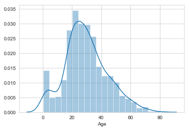

```python
#This is seaborn distplot to understand the data distribution
copy = training.copy()
copy.dropna(inplace = True)
sns.distplot(copy['Age']);
```

Handling the NULLs by using the fillna() method –

1. Filling the NULLs in AGE by its median value
2. Filling Embarked by S (because it occurred most frequently)
3. Filling Fare by its median value

```python
training['Age'].fillna(training['Age'].median(), inplace = True)
testing['Age'].fillna(testing['Age'].median(), inplace = True)
training['Embarked'].fillna('S', inplace = True)
testing['Fare'].fillna(testing['Fare'].median(), inplace = True)
```

```python
print("Nulls information in training datasets:")
pd.isnull(training).sum()
```

```
Nulls information in training datasets:
```

```
PassengerId    0
Survived       0
Pclass         0
Name           0
Sex            0
Age            0
SibSp          0
Parch          0
Fare           0
Embarked       0
dtype: int64
```

```python
print("Nulls information in testing datasets:")
pd.isnull(testing).sum()
```

```
Nulls information in testing datasets:
```

```
PassengerId    0
Pclass         0
Name           0
Sex            0
Age            0
SibSp          0
Parch          0
Fare           0
Embarked       0
dtype: int64
```

```python
training.head()
```

|  | PassengerId | Survived | Pclass | Name | Sex | Age | SibSp | Parch | Fare | Embarked |
| --- | --- | --- | --- | --- | --- | --- | --- | --- | --- | --- |
| 0 | 1 | 0 | 3 | Braund, Mr. Owen Harris | male | 22.0 | 1 | 0 | 7.2500 | S |
| 1 | 2 | 1 | 1 | Cumings, Mrs. John Bradley (Florence Briggs Th... | female | 38.0 | 1 | 0 | 71.2833 | C |
| 2 | 3 | 1 | 3 | Heikkinen, Miss. Laina | female | 26.0 | 0 | 0 | 7.9250 | S |
| 3 | 4 | 1 | 1 | Futrelle, Mrs. Jacques Heath (Lily May Peel) | female | 35.0 | 1 | 0 | 53.1000 | S |
| 4 | 5 | 0 | 3 | Allen, Mr. William Henry | male | 35.0 | 0 | 0 | 8.0500 | S |

```python
testing.head()
```

|  | PassengerId | Pclass | Name | Sex | Age | SibSp | Parch | Fare | Embarked |
| --- | --- | --- | --- | --- | --- | --- | --- | --- | --- |
| 0 | 892 | 3 | Kelly, Mr. James | male | 34.5 | 0 | 0 | 7.8292 | Q |
| 1 | 893 | 3 | Wilkes, Mrs. James (Ellen Needs) | female | 47.0 | 1 | 0 | 7.0000 | S |
| 2 | 894 | 2 | Myles, Mr. Thomas Francis | male | 62.0 | 0 | 0 | 9.6875 | Q |
| 3 | 895 | 3 | Wirz, Mr. Albert | male | 27.0 | 0 | 0 | 8.6625 | S |
| 4 | 896 | 3 | Hirvonen, Mrs. Alexander (Helga E Lindqvist) | female | 22.0 | 1 | 1 | 12.2875 | S |

# 4. Plotting and Visualizing Data

By plotting and visualizing each feature (predictor) against the response (survived), we try to find how a particular feature impacting the predictions to understand which the most significant feature is, and which is the least significant feature. Remember in machine learning its very important to understand the features and how they impact the prediction.

Gender

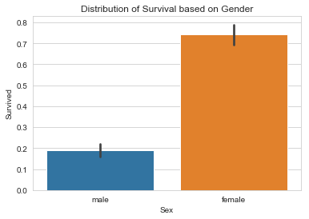

```
Total people survived is: 342
Proportion of Females who survived:
0.6812865497076024
Proportion of Males who survived:
0.31871345029239767
```

```python
#SNS barplot for AGE
sns.barplot(x='Sex', y='Survived', data=training)
plt.title("Distribution of Survival based on Gender")
plt.show()

total_survived_females = training[training.Sex == "female"]["Survived"].sum()
total_survived_males = training[training.Sex == "male"]["Survived"].sum()

print("Total people survived is: " + str((total_survived_females + total_survived_males)))
print("Proportion of Females who survived:")
print(total_survived_females/(total_survived_females + total_survived_males))
print("Proportion of Males who survived:")
print(total_survived_males/(total_survived_females + total_survived_males))
```

Conclusion1: With the above Bar-plot and statistics, we can safely and easily conclude that there are more Female survived than the Males

Class

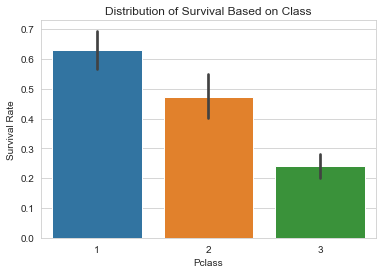

```
Total people survived is: 342
Proportion of Class 1 Passengers who survived:
0.39766081871345027
Proportion of Class 2 Passengers who survived:
0.2543859649122807
Proportion of Class 3 Passengers who survived:
0.347953216374269
```

```python
#seaborn plot for Pclass to understand how the seating class of the passenger affected its survival
sns.barplot(x="Pclass", y="Survived", data=training)
plt.ylabel("Survival Rate")
plt.title("Distribution of Survival Based on Class")
plt.show()

total_survived_one = training[training.Pclass == 1]["Survived"].sum()
total_survived_two = training[training.Pclass == 2]["Survived"].sum()
total_survived_three = training[training.Pclass == 3]["Survived"].sum()
total_survived_class = total_survived_one + total_survived_two + total_survived_three

print("Total people survived is: " + str(total_survived_class))
print("Proportion of Class 1 Passengers who survived:")
print(total_survived_one/total_survived_class)
print("Proportion of Class 2 Passengers who survived:")
print(total_survived_two/total_survived_class)
print("Proportion of Class 3 Passengers who survived:")
print(total_survived_three/total_survived_class)
```

Conclusion2: by looking into the above bar-plot, we can easily conclude that the passenger which were in class 1 and 2 are more likely to survived than who were present in class3

```
Text(0.5,1,'Survival Rates Based on Gender and Class')
```

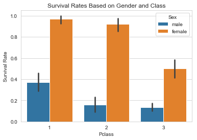

```python
#survival rate is each class based on the gender - it further concludes
#that even in each class there are more women survived than the man
sns.barplot(x="Pclass", y="Survived", hue="Sex", data=training)
plt.ylabel("Survival Rate")
plt.title("Survival Rates Based on Gender and Class")
```

```
Text(0.5,1,'Survival Rates Based on Gender and Class')
```

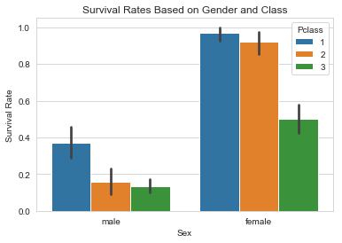

```python
#interchnaging the hue parameter from the above to give more insights
sns.barplot(x="Sex", y="Survived", hue="Pclass", data=training)
plt.ylabel("Survival Rate")
plt.title("Survival Rates Based on Gender and Class")
```

Age

Further digging into the AGE of the survived or not survived passenger to understand if the survival anything to do with passenger’s age

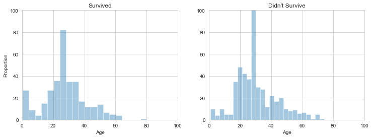

```python
survived_ages = training[training.Survived == 1]["Age"]
not_survived_ages = training[training.Survived == 0]["Age"]
plt.subplot(1, 2, 1)
sns.distplot(survived_ages, kde=False)
plt.axis([0, 100, 0, 100])
plt.title("Survived")
plt.ylabel("Proportion")
plt.subplot(1, 2, 2)
sns.distplot(not_survived_ages, kde=False)
plt.axis([0, 100, 0, 100])
plt.title("Didn't Survive")
plt.subplots_adjust(right=1.7)
plt.show()
```

Conclusion3: So, we can conclude there is no clear-cut evidence which says the AGE is having significant impact on survival. We can se both survival -age and not-survived age data is more and normally distributed.

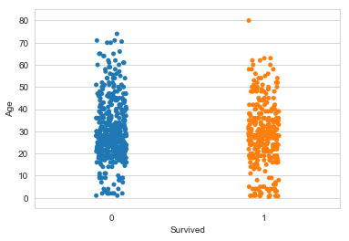

```python
#looking into the AGE feature in a different way
sns.stripplot(x="Survived", y="Age", data=training, jitter=True)
```

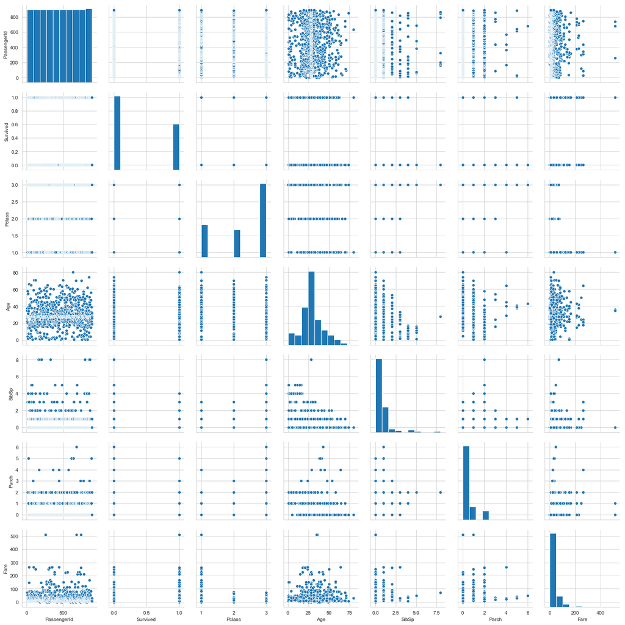

```python
#Plotting every feature
sns.pairplot(training)
```

# 5. Feature Engineering

Because values in the Sex and Embarked columns are categorical values, we have to represent these strings as numerical values in order to perform our classification with our model. We can also do this process through One-Hot-Encoding.

We change Sex to binary, as either 1 for female or 0 for male. We do the same for Embarked. We do this same process on both the training and testing set to prepare our data for Machine Learning.

```python
set(training["Embarked"])
```

```
{'C', 'Q', 'S'}
```

There are 3 values for Embarked: S, C, and Q. We will represent these with numbers as well.

Remember we need to deal the categorical variables in both Train and Test set. There are 2 kinds of categorical variables.

1. Ordinal: which has certain order
2. Nominal: which doesn’t have any order but has fixed sets of categories.

```python
# For Male - 0
# For Female  - 1
training.loc[training["Sex"] == "male", "Sex"] = 0
training.loc[training["Sex"] == "female", "Sex"] = 1

# For S , C , Q - 0, 1 , 2 respectivly

training.loc[training["Embarked"] == "S", "Embarked"] = 0
training.loc[training["Embarked"] == "C", "Embarked"] = 1
training.loc[training["Embarked"] == "Q", "Embarked"] = 2

#Applies the same for Test data set

testing.loc[testing["Sex"] == "male", "Sex"] = 0
testing.loc[testing["Sex"] == "female", "Sex"] = 1

testing.loc[testing["Embarked"] == "S", "Embarked"] = 0
testing.loc[testing["Embarked"] == "C", "Embarked"] = 1
testing.loc[testing["Embarked"] == "Q", "Embarked"] = 2
```

Lets check if we have made a successful replacement or not?

```python
training.sample(5)
```

|  | PassengerId | Survived | Pclass | Name | Sex | Age | SibSp | Parch | Fare | Embarked |
| --- | --- | --- | --- | --- | --- | --- | --- | --- | --- | --- |
| 129 | 130 | 0 | 3 | Ekstrom, Mr. Johan | 0 | 45.0 | 0 | 0 | 6.9750 | 0 |
| 204 | 205 | 1 | 3 | Cohen, Mr. Gurshon "Gus" | 0 | 18.0 | 0 | 0 | 8.0500 | 0 |
| 396 | 397 | 0 | 3 | Olsson, Miss. Elina | 1 | 31.0 | 0 | 0 | 7.8542 | 0 |
| 366 | 367 | 1 | 1 | Warren, Mrs. Frank Manley (Anna Sophia Atkinson) | 1 | 60.0 | 1 | 0 | 75.2500 | 1 |
| 464 | 465 | 0 | 3 | Maisner, Mr. Simon | 0 | 28.0 | 0 | 0 | 8.0500 | 0 |

```python
testing.sample(5)
```

|  | PassengerId | Pclass | Name | Sex | Age | SibSp | Parch | Fare | Embarked |
| --- | --- | --- | --- | --- | --- | --- | --- | --- | --- |
| 57 | 949 | 3 | Abelseth, Mr. Olaus Jorgensen | 0 | 25.0 | 0 | 0 | 7.6500 | 0 |
| 86 | 978 | 3 | Barry, Miss. Julia | 1 | 27.0 | 0 | 0 | 7.8792 | 2 |
| 158 | 1050 | 1 | Borebank, Mr. John James | 0 | 42.0 | 0 | 0 | 26.5500 | 0 |
| 121 | 1013 | 3 | Kiernan, Mr. John | 0 | 27.0 | 1 | 0 | 7.7500 | 2 |
| 365 | 1257 | 3 | Sage, Mrs. John (Annie Bullen) | 1 | 27.0 | 1 | 9 | 69.5500 | 0 |

You can see from the above that we finally able to deal the categorical variables and converted them into numerical.

# Creating Synthetic Features

Sometimes it is useful to create synthetic features that we think may help us predict the target value.

We can combine SibSp and Parch into one synthetic feature called family size, which indicates the total number of family members on board for each member.

```python
#Creating one additinol feature

training["FamSize"] = training["SibSp"] + training["Parch"] + 1
testing["FamSize"] = testing["SibSp"] + testing["Parch"] + 1
```

This IsAlone feature also may work well with the data we're dealing with, telling us whether the passenger was along or not on the ship.

```python
#Creating one more feature named - IsAlone

training["IsAlone"] = training.FamSize.apply(lambda x: 1 if x == 1 else 0)
testing["IsAlone"] = testing.FamSize.apply(lambda x: 1 if x == 1 else 0)
```

Although it may not seem like it, we can also extract some useful information from the name column. Not the actual names themselves, but the title of their names like Ms. or Mr. This may also provide a hint as to whether the passenger survived or not. Therefore we can extract this title and then encode it like we did for Sex and Embarked.

```python
#Creating a feature - Title by extrctacting fron Name column

for name in training["Name"]:
    training["Title"] = training["Name"].str.extract("([A-Za-z]+)\.",expand=True)

for name in testing["Name"]:
    testing["Title"] = testing["Name"].str.extract("([A-Za-z]+)\.",expand=True)
```

```python
#Printing the titles:

titles = set(training["Title"]) #making it a set gets rid of all duplicates
print(titles)
```

```
{'Rev', 'Mme', 'Capt', 'Mrs', 'Major', 'Mr', 'Master', 'Miss', 'Sir', 'Countess', 'Col', 'Jonkheer', 'Lady', 'Dr', 'Mlle', 'Ms', 'Don'}
```

```python
#Checking how many times each title appeared

title_list = list(training["Title"])
frequency_titles = []

for i in titles:
    frequency_titles.append(title_list.count(i))

print(frequency_titles)
```

```
[6, 1, 1, 125, 2, 517, 40, 182, 1, 1, 2, 1, 1, 7, 2, 1, 1]
```

```python
#Printing in a more meaningful way

titles = list(titles)

title_dataframe = pd.DataFrame({
    "Titles" : titles,
    "Frequency" : frequency_titles
})

print(title_dataframe)
```

```
      Titles  Frequency
0        Rev          6
1        Mme          1
2       Capt          1
3        Mrs        125
4      Major          2
5         Mr        517
6     Master         40
7       Miss        182
8        Sir          1
9   Countess          1
10       Col          2
11  Jonkheer          1
12      Lady          1
13        Dr          7
14      Mlle          2
15        Ms          1
16       Don          1
```

```python
#Replacing less frequent titles into - others
title_replacements = {"Mlle": "Other", "Major": "Other", "Col": "Other", "Sir": "Other", "Don": "Other", "Mme": "Other",
          "Jonkheer": "Other", "Lady": "Other", "Capt": "Other", "Countess": "Other", "Ms": "Other", "Dona": "Other"}

training.replace({"Title": title_replacements}, inplace=True)
testing.replace({"Title": title_replacements}, inplace=True)

#encoding the categorical variables into the numerical values

training.loc[training["Title"] == "Miss", "Title"] = 0
training.loc[training["Title"] == "Mr", "Title"] = 1
training.loc[training["Title"] == "Mrs", "Title"] = 2
training.loc[training["Title"] == "Master", "Title"] = 3
training.loc[training["Title"] == "Dr", "Title"] = 4
training.loc[training["Title"] == "Rev", "Title"] = 5
training.loc[training["Title"] == "Other", "Title"] = 6

#repeating for test data set
testing.loc[testing["Title"] == "Miss", "Title"] = 0
testing.loc[testing["Title"] == "Mr", "Title"] = 1
testing.loc[testing["Title"] == "Mrs", "Title"] = 2
testing.loc[testing["Title"] == "Master", "Title"] = 3
testing.loc[testing["Title"] == "Dr", "Title"] = 4
testing.loc[testing["Title"] == "Rev", "Title"] = 5
testing.loc[testing["Title"] == "Other", "Title"] = 6
```

```python
#Droping the name feature - as we have already extracted useful insights from it
training.drop("Name", axis = 1, inplace = True)
testing.drop("Name", axis = 1, inplace = True)
```

```python
training.sample(5)
```

|  | PassengerId | Survived | Pclass | Sex | Age | SibSp | Parch | Fare | Embarked | FamSize | IsAlone | Title |
| --- | --- | --- | --- | --- | --- | --- | --- | --- | --- | --- | --- | --- |
| 296 | 297 | 0 | 3 | 0 | 23.5 | 0 | 0 | 7.2292 | 1 | 1 | 1 | 1 |
| 828 | 829 | 1 | 3 | 0 | 28.0 | 0 | 0 | 7.7500 | 2 | 1 | 1 | 1 |
| 191 | 192 | 0 | 2 | 0 | 19.0 | 0 | 0 | 13.0000 | 0 | 1 | 1 | 1 |
| 734 | 735 | 0 | 2 | 0 | 23.0 | 0 | 0 | 13.0000 | 0 | 1 | 1 | 1 |
| 618 | 619 | 1 | 2 | 1 | 4.0 | 2 | 1 | 39.0000 | 0 | 4 | 0 | 0 |

```python
testing.sample(5)
```

|  | PassengerId | Pclass | Sex | Age | SibSp | Parch | Fare | Embarked | FamSize | IsAlone | Title |
| --- | --- | --- | --- | --- | --- | --- | --- | --- | --- | --- | --- |
| 319 | 1211 | 2 | 0 | 22.0 | 2 | 0 | 31.500 | 0 | 3 | 0 | 1 |
| 244 | 1136 | 3 | 0 | 27.0 | 1 | 2 | 23.450 | 0 | 4 | 0 | 3 |
| 28 | 920 | 1 | 0 | 41.0 | 0 | 0 | 30.500 | 0 | 1 | 1 | 1 |
| 349 | 1241 | 2 | 1 | 31.0 | 0 | 0 | 21.000 | 0 | 1 | 1 | 0 |
| 14 | 906 | 1 | 1 | 47.0 | 1 | 0 | 61.175 | 0 | 2 | 0 | 2 |

WOW! All the features are in numerical form now. It is ready to be fed into our model. Before we do that however, there's something else that we should notice when looking at the preprocessed data. Particularly, the Age and Fare feature values.

# 6. Feature Rescaling

If you take a look at the Age and Fare features above, you can see that the values deviate heavily from the other features. This may potentially cause some problems when we are modelling, and it would be beneficial to scale them so they are more representative. We will do this with sklearn's MinMaxScaler function. This function also requires us to reshape our data so that it accepts the input. The steps are shown below.

```python
#scaling

from sklearn.preprocessing import MinMaxScaler

scaler = MinMaxScaler()

#scaler requires arguments to be in a specific format shown below
#convert columns into numpy arrays and reshape them
ages_train = np.array(training["Age"]).reshape(-1, 1)
fares_train = np.array(training["Fare"]).reshape(-1, 1)
ages_test = np.array(testing["Age"]).reshape(-1, 1)
fares_test = np.array(testing["Fare"]).reshape(-1, 1)

#we replace the original column with the transformed/scaled values
training["Age"] = scaler.fit_transform(ages_train)
training["Fare"] = scaler.fit_transform(fares_train)
testing["Age"] = scaler.fit_transform(ages_test)
testing["Fare"] = scaler.fit_transform(fares_test)
```

```python
#Chceking the training data

training.head()
```

|  | PassengerId | Survived | Pclass | Sex | Age | SibSp | Parch | Fare | Embarked | FamSize | IsAlone | Title |
| --- | --- | --- | --- | --- | --- | --- | --- | --- | --- | --- | --- | --- |
| 0 | 1 | 0 | 3 | 0 | 0.271174 | 1 | 0 | 0.014151 | 0 | 2 | 0 | 1 |
| 1 | 2 | 1 | 1 | 1 | 0.472229 | 1 | 0 | 0.139136 | 1 | 2 | 0 | 2 |
| 2 | 3 | 1 | 3 | 1 | 0.321438 | 0 | 0 | 0.015469 | 0 | 1 | 1 | 0 |
| 3 | 4 | 1 | 1 | 1 | 0.434531 | 1 | 0 | 0.103644 | 0 | 2 | 0 | 2 |
| 4 | 5 | 0 | 3 | 0 | 0.434531 | 0 | 0 | 0.015713 | 0 | 1 | 1 | 1 |

```python
#Chceking the testing data

testing.head()
```

|  | PassengerId | Pclass | Sex | Age | SibSp | Parch | Fare | Embarked | FamSize | IsAlone | Title |
| --- | --- | --- | --- | --- | --- | --- | --- | --- | --- | --- | --- |
| 0 | 892 | 3 | 0 | 0.452723 | 0 | 0 | 0.015282 | 2 | 1 | 1 | 1 |
| 1 | 893 | 3 | 1 | 0.617566 | 1 | 0 | 0.013663 | 0 | 2 | 0 | 2 |
| 2 | 894 | 2 | 0 | 0.815377 | 0 | 0 | 0.018909 | 2 | 1 | 1 | 1 |
| 3 | 895 | 3 | 0 | 0.353818 | 0 | 0 | 0.016908 | 0 | 1 | 1 | 1 |
| 4 | 896 | 3 | 1 | 0.287881 | 1 | 1 | 0.023984 | 0 | 3 | 0 | 2 |

We can see the AGE and FARE features are now on the same scale 😊

This feature scaling may allow for higher accuracy for our models because of the reduced weight of their magnitudes!

# 7. Model Fitting, Optimizing, and Predicting

Now that our data has been processed and formmated properly, and that we understand the general data we're working with as well as the trends and associations, we can start to build our model. We can import different classifiers from sklearn. We will try different types of models to see which one gives the best accuracy for its predictions.

# SKLEARN Models:

```python
warnings.filterwarnings("ignore", category=DeprecationWarning)
from sklearn.svm import SVC, LinearSVC
from sklearn.ensemble import RandomForestClassifier
from sklearn.linear_model import LogisticRegression
from sklearn.neighbors import KNeighborsClassifier
from sklearn.naive_bayes import GaussianNB
from sklearn.tree import DecisionTreeClassifier
```

To evaluate our model performance, we can use the make_scorer and accuracy_score function from sklearn metrics.

```python
from sklearn.metrics import make_scorer, accuracy_score
```

We can also use a GridSearch cross validation to find the optimal parameters for the model we choose to work with and use to predict on our testing set.

```python
from sklearn.model_selection import GridSearchCV
```

# Defining Features in Training/Test Set

```python
X_train = training.drop(labels=["PassengerId", "Survived"], axis=1) #define training features set
y_train = training["Survived"] #define training label set
X_test = testing.drop("PassengerId", axis=1) #define testing features set
#we don't have y_test, that is what we're trying to predict with our model
```

# Validation Data Set

Although we already have a test set, it is generally easy to overfit the data with these classifiers. It is therefore useful to have a third data set called the validation data set to ensure that our model doesn't overfit with the data. We can make this third data set with sklearn's train_test_split function. We can also use the validation data set to test the general accuracy of our model.

```python
from sklearn.model_selection import train_test_split #to create validation data set

X_training, X_valid, y_training, y_valid = train_test_split(X_train, y_train, test_size=0.2, random_state=0) #X_valid and y_valid are the validation sets
```

# SVC Model

```python
svc_clf = SVC()

parameters_svc = {"kernel": ["rbf", "linear"], "probability": [True, False], "verbose": [True, False]}

grid_svc = GridSearchCV(svc_clf, parameters_svc, scoring=make_scorer(accuracy_score))
grid_svc.fit(X_training, y_training)

svc_clf = grid_svc.best_estimator_

svc_clf.fit(X_training, y_training)
pred_svc = svc_clf.predict(X_valid)
acc_svc = accuracy_score(y_valid, pred_svc)
```

[output not shown]

```python
print("The Score for SVC is: " + str(acc_svc))
```

```
The Score for SVC is: 0.776536312849162
```

# LinearSVC Model

```python
linsvc_clf = LinearSVC()

parameters_linsvc = {"multi_class": ["ovr", "crammer_singer"], "fit_intercept": [True, False], "max_iter": [100, 500, 1000, 1500]}

grid_linsvc = GridSearchCV(linsvc_clf, parameters_linsvc, scoring=make_scorer(accuracy_score))
grid_linsvc.fit(X_training, y_training)

linsvc_clf = grid_linsvc.best_estimator_

linsvc_clf.fit(X_training, y_training)
pred_linsvc = linsvc_clf.predict(X_valid)
acc_linsvc = accuracy_score(y_valid, pred_linsvc)

print("The Score for LinearSVC is: " + str(acc_linsvc))
```

```
The Score for LinearSVC is: 0.7932960893854749
```

# RandomForest Model

```python
rf_clf = RandomForestClassifier()

parameters_rf = {"n_estimators": [4, 5, 6, 7, 8, 9, 10, 15], "criterion": ["gini", "entropy"], "max_features": ["auto", "sqrt", "log2"],
                 "max_depth": [2, 3, 5, 10], "min_samples_split": [2, 3, 5, 10]}

grid_rf = GridSearchCV(rf_clf, parameters_rf, scoring=make_scorer(accuracy_score))
grid_rf.fit(X_training, y_training)

rf_clf = grid_rf.best_estimator_

rf_clf.fit(X_training, y_training)
pred_rf = rf_clf.predict(X_valid)
acc_rf = accuracy_score(y_valid, pred_rf)

print("The Score for Random Forest is: " + str(acc_rf))
```

```
The Score for Random Forest is: 0.8379888268156425
```

# LogisiticRegression Model

```python
logreg_clf = LogisticRegression()

parameters_logreg = {"penalty": ["l2"], "fit_intercept": [True, False], "solver": ["newton-cg", "lbfgs", "liblinear", "sag", "saga"],
                     "max_iter": [50, 100, 200], "warm_start": [True, False]}

grid_logreg = GridSearchCV(logreg_clf, parameters_logreg, scoring=make_scorer(accuracy_score))
grid_logreg.fit(X_training, y_training)

logreg_clf = grid_logreg.best_estimator_

logreg_clf.fit(X_training, y_training)
pred_logreg = logreg_clf.predict(X_valid)
acc_logreg = accuracy_score(y_valid, pred_logreg)

print("The Score for Logistic Regression is: " + str(acc_logreg))
```

```
The Score for Logistic Regression is: 0.7877094972067039
```

# KNeighbors Model

```python
knn_clf = KNeighborsClassifier()

parameters_knn = {"n_neighbors": [3, 5, 10, 15], "weights": ["uniform", "distance"], "algorithm": ["auto", "ball_tree", "kd_tree"],
                  "leaf_size": [20, 30, 50]}

grid_knn = GridSearchCV(knn_clf, parameters_knn, scoring=make_scorer(accuracy_score))
grid_knn.fit(X_training, y_training)

knn_clf = grid_knn.best_estimator_

knn_clf.fit(X_training, y_training)
pred_knn = knn_clf.predict(X_valid)
acc_knn = accuracy_score(y_valid, pred_knn)

print("The Score for KNeighbors is: " + str(acc_knn))
```

```
The Score for KNeighbors is: 0.7988826815642458
```

# GaussianNB Model

```python
gnb_clf = GaussianNB()

parameters_gnb = {}

grid_gnb = GridSearchCV(gnb_clf, parameters_gnb, scoring=make_scorer(accuracy_score))
grid_gnb.fit(X_training, y_training)

gnb_clf = grid_gnb.best_estimator_

gnb_clf.fit(X_training, y_training)
pred_gnb = gnb_clf.predict(X_valid)
acc_gnb = accuracy_score(y_valid, pred_gnb)

print("The Score for Gaussian NB is: " + str(acc_gnb))
```

```
The Score for Gaussian NB is: 0.7821229050279329
```

# DecisionTree Model

```python
dt_clf = DecisionTreeClassifier()

parameters_dt = {"criterion": ["gini", "entropy"], "splitter": ["best", "random"], "max_features": ["auto", "sqrt", "log2"]}

grid_dt = GridSearchCV(dt_clf, parameters_dt, scoring=make_scorer(accuracy_score))
grid_dt.fit(X_training, y_training)

dt_clf = grid_dt.best_estimator_

dt_clf.fit(X_training, y_training)
pred_dt = dt_clf.predict(X_valid)
acc_dt = accuracy_score(y_valid, pred_dt)

print("The Score for Decision Tree is: " + str(acc_dt))
```

```
The Score for Decision Tree is: 0.7653631284916201
```

# 8. Evaluating Model Performances

After making so many models and predictions, we should evaluate and see which model performed the best and which model to use on our testing set.

```python
model_performance = pd.DataFrame({
    "Model": ["SVC", "Linear SVC", "Random Forest",
              "Logistic Regression", "K Nearest Neighbors", "Gaussian Naive Bayes",
              "Decision Tree"],
    "Accuracy": [acc_svc, acc_linsvc, acc_rf,
              acc_logreg, acc_knn, acc_gnb, acc_dt]
})

model_performance.sort_values(by="Accuracy", ascending=False)
```

|  | Model | Accuracy |
| --- | --- | --- |
| 2 | Random Forest | 0.837989 |
| 4 | K Nearest Neighbors | 0.798883 |
| 1 | Linear SVC | 0.793296 |
| 3 | Logistic Regression | 0.787709 |
| 5 | Gaussian Naive Bayes | 0.782123 |
| 0 | SVC | 0.776536 |
| 6 | Decision Tree | 0.765363 |

It appears that the Random Forest model works the best with our data so we will use it on the test set.

# 9. Submission

Let's create a dataframe to submit to the competition with our predictions of our model.

```python
rf_clf.fit(X_train, y_train)
```

```
RandomForestClassifier(bootstrap=True, class_weight=None, criterion='entropy',
            max_depth=5, max_features='auto', max_leaf_nodes=None,
            min_impurity_decrease=0.0, min_impurity_split=None,
            min_samples_leaf=1, min_samples_split=10,
            min_weight_fraction_leaf=0.0, n_estimators=8, n_jobs=1,
            oob_score=False, random_state=None, verbose=0,
            warm_start=False)
```

```python
submission_predictions = rf_clf.predict(X_test)
```

```python
submission = pd.DataFrame({
        "PassengerId": testing["PassengerId"],
        "Survived": submission_predictions
    })

submission.to_csv("C:/Users/deepak.rajak/Documents/Titanic/titanic_randomforest.csv", index=False)
print(submission.shape)
```

```
(418, 2)
```

```python
submission_predictions
```

[output not shown]